# Final Paper

STOR 320.01 Group 13

December 4, 2019

# INTRODUCTION

> Battle-Royale-style Esports has engaged hundreds of millions of players in its recent reign in the video game industry with the popularization of games such as PlayerUnknown’s Battlegrounds (PUBG) and Fortnite. The high-level competition with a range of available weapons, vehicles, and map locations allow players to put their tactical skills to the test with the ultimate goal of being the final man/team standing.PlayerUnknown’s Battlegrounds (PUBG) is one of several Battle-Royale video games to achieve widespread popularity over the past few years. Initially released in 2017 with one map, PUBG has expanded to include three additional maps with different game modes. A game of PUBG includes up to 100 players and begins with players skydiving onto the map. The goal of the game is to be the last player standing on the map, which is populated with various weapons, buildings, vehicles and towns. To drive players towards each other, a large circle shrinks onto a randomized point on the map- players outside the circle take health damage at a rate that ensures survival outside the circle to be impossible, fostering more player-vs-player fighting as they are cooped into increasingly smaller spaces.

> Naturally, players seek strategies to improve their chances of winning. We have obtained and performed an analysis on nearly 10,000 games, from which we have derived insights about the substance of the game and its players. It is important to note that weapons are spawned on or inside of buildings, and locations with many buildings have more diverse and numerous weapons than isolated locations. Vehicles typically appear alongside roads, though they are also thought to be more numerous in large named locations. This gives players an incentive to skydive towards named locations, as it would give them a better chance of finding weapons. It must be stated that this is conventional wisdom obtained from playing the game and speaking with players, and only the developer knows the methodology for the generation of items on the map.The questions that we sought to answer are as follows:
- **Which aggregate player variables most reliably predict player survival time and how can we use a model to predict survival time?**
- **Which player death variables most reliably predict player player success and how can we use a model to predict player success?**

> Our initial goal was to build a model that can accurately predict a player’s survival time based off of aggregate player variables. These questions are valuable for both casual and serious players, as they indicate what strategies players use to achieve success and higher survival times. While only one person can win the game, the intrinsic value of placing well in a game can be as much as winning itself for some players. As with most shooter video games, the result is largely determined by luck and the presence of some “x factor”- this could come down to things like game-instinct, aiming skills or tactical knowledge, which are nearly impossible to measure. While we cannot speak to these skills, we can describe some behaviors of successful players, from which the reader can gain strategic insight and game developers can derive a better understanding of the implications of any proposed changes. For example, are some guns so overpowered that they almost guarantee player success? For the developer, they can evaluate how parameters in their simulation effect real player behavior. It must be assumed that nothing in the game is truly random, rather contrived by the developers so as to foster competition and fun gameplay.

# DATA

> We obtained the data from the online repository Kaggle, published by user “skihikingkevin” in 2017. This user scraped the data from pubg.op.gg, which tracks game data from PUBG matches played on Steam, a video game distributor. As this data is from Steam and dated to 2017, well before PUBG Corporation added cross-platform compatibility, the games must have been played by exclusively PC players. User ‘skihikingkevin’ explains potential bias in his description of the dataset: the scraping was performed using a single seed player, branching to a random subset 5000 players out of all players that this initial seed encountered. PUBG uses a ranking system to create games, grouping players with similarly-ranked players to ensure fair competition. User ‘shihikingkevin’ indicates that the initial seed player was of slightly below average rank, and as such, the data should not be taken to represent the highest levels of competitive play. Rather, it can be understood to show games played by casual players. From this, insights can be gathered as to the behaviors of both successful and unsuccessful players at this level of competition.

> The data we used is comprised of two datasets: aggregated match statistics and death event statistics. In our dataset, there are an average of 95 players per game, and both datasets store a single game in ~95 rows- each of which contains data about a game played by an in. We subsetted these massive (roughly 2GB each) datasets to obtain data from nearly one million unique rows. This was accomplished by picking two 2GB csv files, randomly sampling from unique match_id values, and retaining those observations whose match_id was in the sampled values. With almost 100 rows corresponding to a single game, each dataset had around 900,000 rows, though there are 9000 unique games. After filtering out non-Erangel map data, the dataset had around 700,000 rows and 7000 unique games. The important insight is that the aggregate dataset has information on the match as a whole, while the death-event dataset gives information that corresponds to specific points of time.

> The aggregate dataset includes variables describing individual players such as time survived by player (**player_survival_time**), damage inflicted (**player_dmg**), overall placement (**team_placement**, in our case the “team” is the solo player), number of kills (**player_kills**), player name (player_name), and travel distance (**player_dist_walk** for walking and **player_dist_ride** for vehicular travel), all of which are numerical variables. It also includes match-specific data: the most important of these being the match mode (third-person or first-person perspective), party size (between one and four players per team), game length, map, and a match_id value. These match-data do not appear in our analysis and were only used for data cleaning. We decided to focus on exclusively third-person perspective, single party size games on the Erangel map, as play styles and outcomes can be very different across the game types and maps. Time variables are recorded in seconds in both datasets.

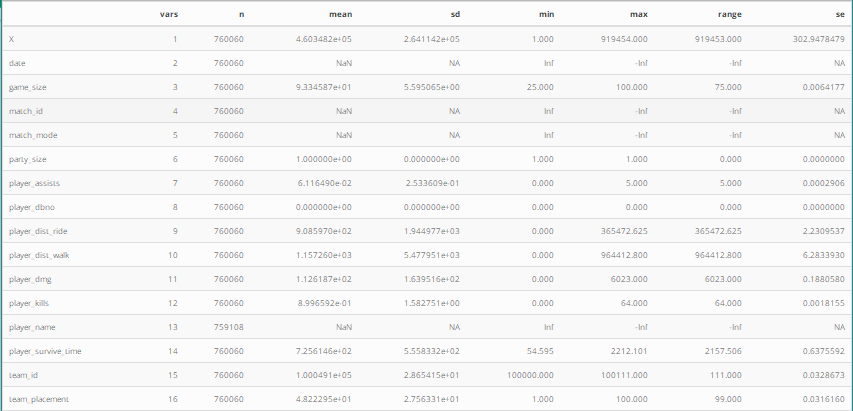

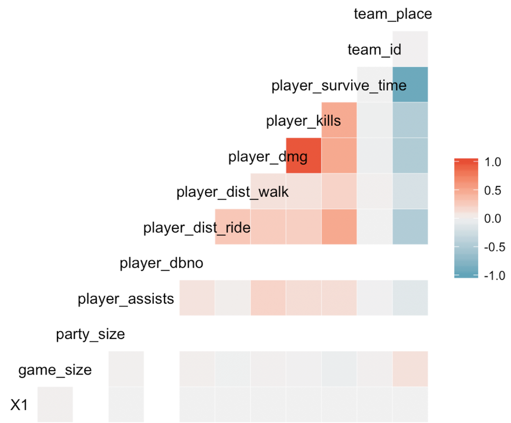

> The death event dataset is built of variables that describe a single death, the player’s name, x and y positional data about the victim and killer (if applicable) (**killer_position_x**, **killer_position_y**,**victim_position_x** and **victim_position_y**), time of death (**time**), and the weapon or cause of death (**killed_by**). Also included are the **killer_placement** and **victim_placement** variables, integers ranging from 1 to 100 indicating how well the player did - a lower number means a better performance, with 1st place being the winner. The positional data is taken directly from PUBG’s coordinates, which range from 0 to 800,000 on both x and y. There is not always a killer; a player can be killed by falling. Each row represents one death, with a match_id value tying it to other rows from the same game in both datasets.

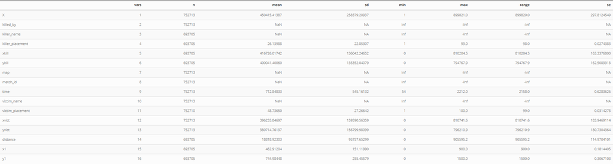

[figure not shown]

> We derived the average distance between a player’s kills for players with 2 or more kills. This was done by sorting a player’s kills according to time, and averaging euclidean distances between each event. In calculating this distance, we found that player ride and walk distances were scaled differently from the original positional data, and probably represent a common unit of measurement rather than raw the positional scale. The location of where a player landed on the map was not given- however, death events occurring before 2 minutes had elapsed in-game are indicative of where some players began their journey on the map. We created scaled copies of positional data to plot on top of a JPEG image of the Erangel map.

# Results

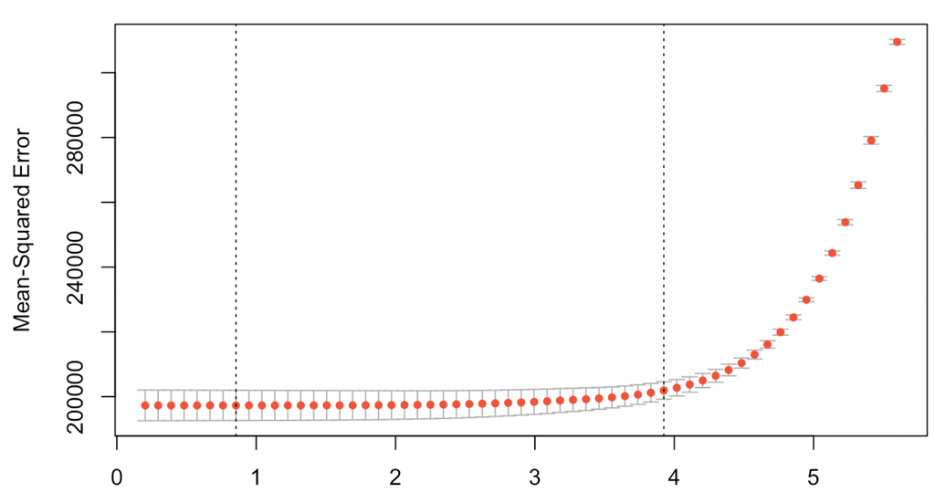

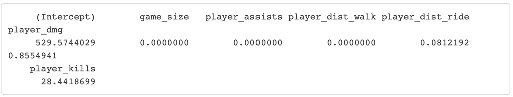

> For the second question, we chose to focus on the death-event dataset. As its rows do not represent cumulative game outcome data, we were interested to see if it could match any of the predictive power of the models above. We sought to examine outcomes by looking at a selection of kills which only give a small glimpse into the game. Our exploration of the death events was enabled by scaling the positional data so that it could be plotted on a JPEG image of the map. We used the killer_placement variable to focus on players with at least one kill, as we wanted to focus on this portion of the analysis on successful players. While we do not have data on where players landed, death locations in the first few minutes of the game give a nice picture of where players were early on. Given the size of the map, it is not typical for players to travel far in the early game- players who die in the first 500 seconds walk and ride an average of 220 and 61 units, respectively. As mentioned in the introductory section, players are known to cluster at marked locations on the map. We see in the plot of death density by game time that the majority of deaths occur in the first ~500 seconds, and slowly decrease after this initial spike.

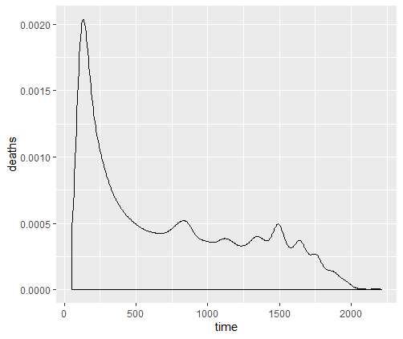

> It is natural that high rates of death occur at locations where players cluster, and this can be observed in the heatmap below: the three locations highlighted by the plot are the military base, Pochinki and School.

[figure not shown]

> We noticed these “hot” locations, where deaths occur more frequently than anywhere else. Another heat map below shows that this trend carries over past the first 500 seconds, with these locations still having significantly higher deaths than the rest of the map.

[figure not shown]

> To further investigate this, we used ggplot’s stat_bin2d function to bin the positional data, noting the bins with disproportionately high densities. With these bins, we created a categorical variable called isolatedLocation to indicate that the event occurred outside of the “hot” zones. The boxplots below show the average overall placement of the killer in death events happening in the first 120 seconds of the game, categorized by whether the kill occurred in an isolated location or not. Recall from the models above that player_kills correlates positively with survival time. This plot, however, shows that players whose first kill is outside of the hot zones perform significantly better overall than those whose first kill is within a hot zone. This chart does not include players who had no kills.

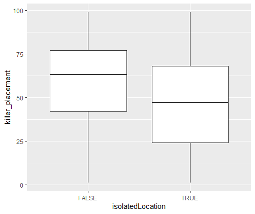

> This is somewhat intuitive, as the high number of deaths in these popular locations would imply a high probability of death in such places. This extends even outside of the first 120 seconds. The plot below shows average killer placement, grouped by whether or not the kill occurred in a hot zone. It is seen once again that players who hang out in these high-traffic areas do significantly worse than those who do not.

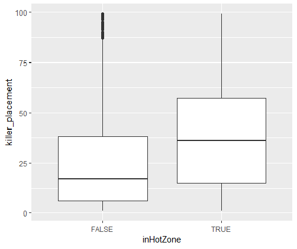

> Observing the plot of kills in the first 120 seconds by players placing in the top 5 overall, it is clear that these players are landing all around the map. Using a similar binning technique to the one described above, we found that only ⅓ of top 5 players land in hot zones. The distinct ring formed around the map lines up with roads that provide vehicle spawn points and the safest vehicular transportation (the danger of off-road travel with vehicles is well documented). From the figure showing variable correlations, we see that player vehicular travel distance correlates positively with survival time. Although it is impossible to quantify how much vehicles help, it is certain that successful players are indeed using vehicles. One might speculate that these successful players are deliberately seeking a vehicle, though an exploration of vehicle travel distance of top 5 players based on whether or not they landed in hot zones shows only a slight difference between the two groups. However, both groups have high average vehicle usage, exemplifying the general correlation described above.

> Returning to the 500 second critical window, we investigated whether outcomes in this time could have a predictive effect on player success. We sought to make a linear model to predict **killer_placement** using data with a killer that occurred before 500 seconds. That is, we sought to build a model to predict how well players did, given that they had a kill in the first 500 seconds of the game. To achieve this, we used 10-fold cross validation on the data and obtained a MSE from the predictions. Our model showed that players who made kills in a hot zone were nearly 8 places behind those who avoided it, on average. Interestingly enough, the strongest predictors of success were if the killer used a boat, an m249, or an mk14. These gave the killer an average difference of -26, -13, and -12 placement positions, respectively. Using the same techniques as above, this model gave a mse indicating that predictions differed by ~22 placements. After this, we added the distance between the killer and victim to the model - this gave different results. The hot zone coefficient was unchanged, but the weapons mentioned above had significantly less-strong coefficients, though they were equally significant. The Scar-L emerged as the strongest weapon coefficient. Distance gave a statistically significant coefficient, with larger distances between players leading to better **killer_placement**. This model also gave an MSE that, when squared, showed an average difference of 22 positions. Using this model to estimate **player_survive_time** gave a squareroot-MSE of 531 seconds, indicating that the model was off by this much in predictions. This is worse than the model using aggregate data, but still holds value- it shows that the first 500 seconds of the game can be used to predict player outcomes. This tells us that despite having predictive value, there are many other factors at play besides those we can evaluate through this data. As discussed in the introduction, luck, aiming skill and instinct are likely important.

> While we know some general data about players, each game is a mystery to all other than those who played in it. Correlations present do not indicate causation. It is only appropriate for us to speak on information of what players were doing- take from this what you will. PUBG players who read this should note the higher risk of death in certain areas, as well as guns that correlate with endgame success. Players should understand that vehicles are used by successful players, though driving around in circles to increase one’s **player_dist_ride** value is probably not a meaningful strategy. Vehicle usage could be a consequence of surviving longer and needing to travel towards the circle, rather than a cause of success. While not impossible, it is much more difficult to succeed if lingering in a hot zone. Making it past the first 500 seconds gives a player a strong chance at winning the game.

# Conclusion

> The purpose of this analysis of the PlayerUnknown’s Battlegrounds (PUBG) dataset was to build a model that can accurately predict a player’s survival time and success based off of death and aggregate player variables. The questions we answered were:
- **Which aggregate player variables most reliably predict player survival time and how can we use a model to predict survival time?**
- **Which player death variables most reliably predict player player success and how can we use a model to predict player success?**

> These questions were answered using multiple statistical models. Our analysis provided us with some behavioral trends of successful players, from which the reader can gain strategic insight into succeeding at this game. Upon analyzing the survival time and kill locations, we note that players that died in the first 500 seconds walked and rode an average of 220 and 61 units respectively. There is a trend in deaths as the majority appear to occur in the first 500 seconds and decrease thereon out. Using a heatmap, we pointed out the “hot spots” - where deaths occur the most - which were the school, the military base and Pochinki throughout the game. Using the boxplots, we also find that players whose first kill is outside of the hot zones perform significantly better overall than those whose first kill is within a hot zone. This result was expected as moving in the hot zones represents a high probability of being killed. We used binning techniques to find the fraction of players that land in the hot zones and found that only one third of the players do. Successful players are seen to have high vehicle usage which validates the positive correlation between vehicular travel distance and survival time.

> These results are valuable to PUBG players as well as the developer. In creating a simulated world like PUBG, the developer is able to control only a few parameters. The free will of the individual player dictates outcomes in the game. The work that we performed gives valuable insights to the developer. It shows them, in essence, what players are doing- where they are killing or getting killed, with which weapons or objects this is affected. Other key points for the developer include the fact that successful players use vehicles much more than unsuccessful players. One has to wonder whether finding a vehicle is the true driver of a player’s success. As it stands, this is a very important part of the game, whether the developer wants it to be or not. And equally, powerful weapons seem to be a driving force for player success. The results obtained pointing to ideal weapon choices is a sign of another potentially game-breaking feature that developers should be aware of. If winning or losing a game comes down to finding a car, grabbing a scar-L and avoiding high-conflict areas, is this truly fun for players? And is it the way that the game was intended to be played? Only PUBG corp can truly understand our results in this manner, as they know their own large-scale goals for the game. From a resource-management perspective, being able to predict long-run average game times could aid PUBG Corp in minimizing server costs.

> Players can derive value from the same insights given above. The results indicate that there are strategies used by successful players, and emulating these could result in better performance for the casual player. As we have discussed, this has no real importance for serious or professional players, many of whom have already studied the game extensively. At the casual level, though, it can help the player understand better the behavior of both the majority of players as well as the successful minority. Natural extensions of this research are numerous. Firstly, it would be valuable to look at first person games and games with teams larger than 1 player. Secondly, it would be interesting to see how this data compares to that of the other map(s). Further, it would be interesting to look at how often individual players are playing games over time to understand changes in popularity. It would be valuable to look at long-run outcomes for different players, averaging their game performances to determine whether different play styles are yielding improvements or not. It would helpful to have metrics like player accuracy and outcomes of player-vs-player encounters.